# Capstone Project - Text Mining - Exploratory Data Analysis on Datasets to Predict next Words

Pala

March 15, 2016

## Data Processing

### Loading Data

Data files downloaded from Capstone Dataset to filesystem. Setting up source folders for original data files, sample files, and swear words file to read from filesystem. Below code checks for riginal source folder, creates it if one does not exist, and unzip files after donwload.

```r
#Loading tm library by supressing messages and warnings
suppressMessages(suppressWarnings(library(tm)))
```

```r
#source directory for data
sourcedir <- "C:/Data/Development/datascience/coursera/R/data/DataScienceCapstone/final/en_US"
sampledir <- "C:/Data/Development/datascience/coursera/R/data/DataScienceCapstone/sample/en_US"
swearwordsdir <- "C:/Data/Development/datascience/coursera/R/data/DataScienceCapstone/swearwords"

if(!file.exists("C:/Data/Development/datascience/coursera/R/data/DataScienceCapstone/final/en_US")){
        webURL <- "https://d396qusza40orc.cloudfront.net/dsscapstone/dataset/Coursera-SwiftKey.zip"
        download.file(webURL,"C:/Data/Development/datascience/coursera/R/data/DataScienceCapstone")
        #unzip to target folder
        unzip("C:/Data/Development/datascience/coursera/R/data/DataScienceCapstone/Coursera-SwiftKey.zip",
              "C:/Data/Development/datascience/coursera/R/data/DataScienceCapstone");
}
```

```r
twittertext <- readTxtFile(sourcedir,"en_US.twitter.txt")
blogtext  <- readTxtFile(sourcedir,"en_US.blogs.txt")
newstext  <- readTxtFile(sourcedir,"en_US.news.txt")

#Data frame to print file statistics
docs_details <- data.frame("Source" = c("blogs","news","twitter"),
                           "FileSize"=sapply(list(blogtext,newstext,twittertext), docSize),
                           "Length"=sapply(list(blogtext,newstext,twittertext), docLength),
                           "Caracters"=sapply(list(blogtext,newstext,twittertext), docChars))
#summary
docs_details
```

```
##    Source FileSize  Length Caracters
## 1   blogs 248.5 Mb  899288 208361438
## 2    news 249.6 Mb 1010242 203791405
## 3 twitter 301.4 Mb 2360148 162384825
```

```r
#Sampling data:: Getting 20% of sample data
writeTxtFile(sampledir,iconvText(sample(twittertext, docLength(twittertext) * 0.02)),"sample.twitter.txt")
writeTxtFile(sampledir,iconvText(sample(blogtext, docLength(blogtext) * 0.02)),"sample.blogs.txt")
writeTxtFile(sampledir,iconvText(sample(newstext, docLength(newstext) * 0.02)),"sample.news.txt")
```

## Exploratory Data Analysis

### Creating Courps object with sample data and perform below operations

. remove special characters  
. replace some characters with space  
. remove spaces  
. remove punctuations  
. remove repeated characters  
. remove numbers  
. strip white spaces  
. remove stopwords  
. converting lowercase

```r
#Loading libraries
suppressMessages(suppressWarnings(library(SnowballC)))
suppressMessages(suppressWarnings(library(RWeka)))

docs <- Corpus(DirSource(sampledir))
#[1] "sample.blogs.txt"   "sample.news.txt"    "sample.twitter.txt"
docs
```

```
## <<VCorpus>>
## Metadata:  corpus specific: 0, document level (indexed): 0
## Content:  documents: 3
```

Cleaning Coupus and printing top 10 words which has higher frequency

```r
#cleaning corpus text
docs <- tm_map(docs, replaceWithSpace,"-")
docs <- tm_map(docs, removeChar,"`")
docs <- tm_map(docs, removeChar,"`")
docs <- tm_map(docs, removeChar,"´")
docs <- tm_map(docs, removeChar,"!")
docs <- tm_map(docs, replaceWithSpace,":")
docs <- tm_map(docs, removePunctuation)
docs <- tm_map(docs, removeRepeatedChars)
docs <- tm_map(docs, content_transformer(tolower))
docs <- tm_map(docs, removeNumbers)
docs <- tm_map(docs, removeLinks)
docs <- tm_map(docs, stripWhitespace)
docs <- tm_map(docs, PlainTextDocument)
#docs <- tm_map(docs, stemDocument)

#printing top 10 words frequency
printWordFrequency(docs, 10)
```

```
##      term occurrences
## that that       20363
## with with       14023
## this this       10909
## have have       10366
## from from        7473
## they they        6325
## will will        6297
## your your        6103
## just just        6090
## said said        6068
```

```r
#DTM for Corpus - words which has length >4 & < 20 from three files
dtmr <- DocumentTermMatrix(docs, control=list(wordLengths=c(4,20), bounds = list(global = c(3,27))))
crpsfreq <- colSums(as.matrix(dtmr))
```

### Wordcloud

Printing Corpus wordcould to check words frequency before removing stopwords & profanity words  
**Note:** *Please check ‘Common functions’ listed below*

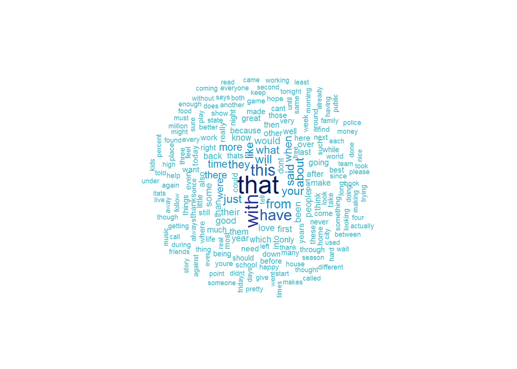

```r
suppressMessages(suppressWarnings(library(wordcloud)))
set.seed(9)
pal <- brewer.pal(9,"YlGnBu")
pal <- pal[-(1:4)]
#ordrfq <- order(crpsfreq, decreasing = TRUE)
wordcloud(names(crpsfreq),crpsfreq, min.freq = 70, scale=c(2,0.5), max.words=200, random.order=FALSE,
          rot.per=0.35, use.r.layout=FALSE, colors=pal)
```

```r
rm(dtmr)
rm(crpsfreq)
```

Downloaded [profanity](http://www.freewebheaders.com/wordpress/wp-content/uploads/full-list-of-bad-words-banned-by-google-txt-file.zip) words (though I named as swear words) and placed int filesystem. Removing profanity words from Corpus  
Removing english stop words from data to get more meaningful words frequency  
Printing top words which has higher frequency

```r
#Loading profanity workds
swearwords <- readTxtFile(swearwordsdir,"swearWords.txt")
#Removing profanity words to get useful words count
docs <- tm_map(docs, removeWords, stopwords('english'))
#Profanity filtering - removing profanity and other words you do not want to predict
docs <- tm_map(docs, removeWords, swearwords)
#Checking word frequency which has length > 4 & < 20 in three files
printWordFrequency(docs, 10)
```

```
##          term occurrences
## will     will        6297
## just     just        6090
## said     said        6068
## like     like        5459
## time     time        4502
## good     good        3532
## love     love        3220
## know     know        3170
## people people        3128
## back     back        2849
```

```r
#findFreqTerms(docs, lowfreq = 200)
```

### N-Gram Tokenization

Creating 1-Gram, 2-Gram, and 3-Gram tokenizers to create TermDocumentMatrix to proceed with Analysis  
Removing Corpus object from memory after usage. This object will not be referred in further analysis  
Executing 1-Gram, 2-Gram, and 3-Gram tokenizers on data

```r
options(mc.cores=1)

#Tokenizers
unitokenizer <- function(x){NGramTokenizer(x,Weka_control(min=1, max=1))}
biotokenizer <- function(x){NGramTokenizer(x,Weka_control(min=2, max=2))}
tritokenizer <- function(x){NGramTokenizer(x,Weka_control(min=3, max=3))}

#Tokenization
UniMatrix <- TermDocumentMatrix(docs, control=list(tokenize=unitokenizer))
BiMatrix <- TermDocumentMatrix(docs, control=list(tokenize=biotokenizer))
TriMatrix <- TermDocumentMatrix(docs, control=list(tokenize=tritokenizer))

#removing docs from memory
rm(docs)
```

```r
gc(reset = TRUE)
```

### Frequency Analysis

#### Loading ‘wordcould’ and ‘ggplot2’ libaries for printing wordcould (for unitokenized data) and plots

```r
suppressMessages(suppressWarnings(library(ggplot2)))

unifreq <- rowSums(as.matrix(UniMatrix))
unifreq <- unifreq[order(unifreq,decreasing = TRUE)]
#Quantiles
printQuantile(unifreq)
```

```
##   0%  25%  50%  75%  80%  90%  95% 100%
##    1    1    1    4    6   16   41 6297
```

Printing unifrequency words

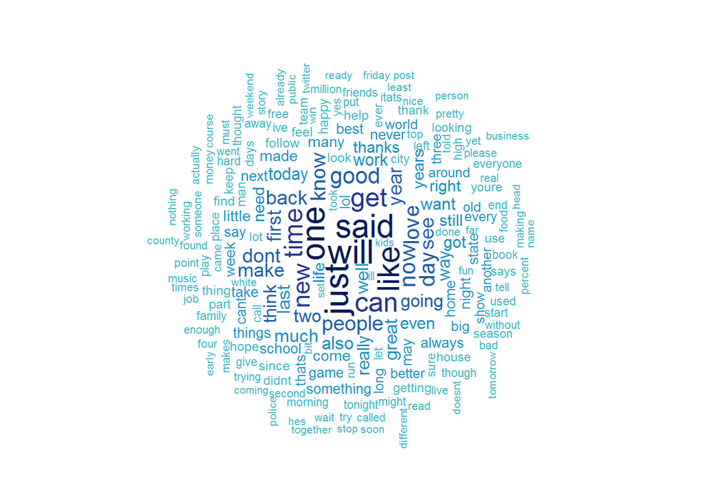

```r
set.seed(9)
pal <- brewer.pal(9,"YlGnBu")
pal <- pal[-(1:4)]
wordcloud(names(unifreq),unifreq,min.freq = 70, scale=c(2,0.5), max.words=200, random.order=FALSE,
          rot.per=0.35, use.r.layout=FALSE, colors=pal)
```

### More Frequent UnigramTokens (1-gram), BigramTokens (2-gram), and TrigramTokens (3-gram) words

Ploting more frequent words graphs

[figure not shown]

```r
printGgPlot(unifreq)
```

### BigramTokens plot

```r
#Bi-frequency for unique workds
bifreq <- rowSums(as.matrix(BiMatrix))
bifreq <- bifreq[order(bifreq,decreasing = TRUE)]
#Quantiles
printQuantile(bifreq)
```

```
##   0%  25%  50%  75%  80%  90%  95% 100%
##    1    1    1    1    1    2    2  502
```

[figure not shown]

```r
printGgPlot(bifreq)
```

### TrigramTokens plot

```r
trifreq <- rowSums(as.matrix(TriMatrix))
trifreq <- trifreq[order(trifreq,decreasing = TRUE)]
#Quantiles
printQuantile(trifreq)
```

```
##   0%  25%  50%  75%  80%  90%  95% 100%
##    1    1    1    1    1    1    1   68
```

[figure not shown]

```r
printGgPlot(trifreq)
```

#### How many unique words do you need in a frequency sorted dictionary to cover 50% of all word instances in the language? 90%?

. 50% Coverage  
. 90% Coverage  
. 95% Coverage

**Note:** *Please check ‘Common functions’ listed below*

```r
#50% coverage
dictCoverage(as.data.frame(unifreq), 0.50)
```

```
## [1] 990
```

```r
#90% coverage
dictCoverage(as.data.frame(unifreq), 0.90)
```

```
## [1] 15615
```

```r
#95% coverage
dictCoverage(as.data.frame(unifreq), 0.95)
```

```
## [1] 32203
```

Higher frequencies giving more words from the dictionary

## Conclusion

This analysis concludes that bigram and trigram models will not be sutable as we cannot predict much so far. We could increase the sample data size and develop probabilistic approach where quad-grams are unobserved. Increasing the sample data requires more computational power and impact the efficiency of the application.

## Next Steps

Following steps will be perfomed for final analysis, build a model, and prediction:

. Execte N-Gram modelling against full data files by optimizing the model to consume low memory  
. Develop final model as a ShinyApp/data product

### Common functions

```r
#Common functions to get size, length, and number of characters in a file
readTxtFile <- function(srcdir,x)
{
        con <- file(paste(srcdir,sep = "/",x),'rb',blocking = FALSE)
        txtFile <- readLines(con, warn = FALSE)
        close(con)
        return(txtFile)
}

writeTxtFile <- function(srcdir,d,x)
{
        con <- file(paste(srcdir,sep = "/",x),blocking = FALSE,raw = FALSE,open = "wt", encoding = "UTF-8")
        txtFile <- writeLines(d,con)
        close(con)
}

printWordFrequency <- function(crps, nm){
        dtmtrx <- DocumentTermMatrix(crps, control=list(wordLengths=c(4,20), bounds = list(global = c(1,3))))
        frqncy <- colSums(as.matrix(dtmtrx))
        #Word frequency data frome
        wf = data.frame(term=names(frqncy), occurrences=frqncy)
        #printing first 10 max occurred terms
        return(head(wf[with(wf, order(-occurrences, term)), ], nm))
}

printGgPlot <- function(dtmarix) {
        freq <- sort(rowSums(as.matrix(dtmarix)), decreasing=TRUE)
        freq_frame <- data.frame(Word=names(freq), Frequency=freq)
        #return(freq_frame)
        freq_frame <- head(freq_frame, 25)
        ggplot(freq_frame, aes(x=Word,y=Frequency)) + geom_bar(stat="Identity", fill=c("#999999")) +geom_text(aes(label=Frequency), vjust=-0.20) + theme(axis.text.x = element_text(angle = 45, hjust = 1, size = 15)) + theme(axis.text.y = element_text(hjust = 1, size = 15))+ theme(axis.title.x = element_text(size = 18)) + theme(axis.title.y = element_text(size = 18))
}

printQuantile <- function(dfreq){
        iquant <- quantile(dfreq,probs=c(0,25,50,75,80,90,95,100)/100)
        print(iquant)
}
#Checking dictionary coverage %
dictCoverage <- function (tdmtrx, prcnt)
{
        freq <- 0
        prcntfreq <- prcnt * sum(tdmtrx[1])
        for (i in 1:nrow(tdmtrx)) {
                if (freq >= prcntfreq) {
                        return (i)
                }
                freq <- freq + tdmtrx[i, 1]
        }
        return (nrow(tdmtrx))
}

#to get file statistics
iconvText <- function(x){return(iconv(x, to='ASCII//TRANSLIT'))}
docSize <- function(x){format(object.size(x),"MB")}
docLength <- function(x){return(length(x))}
docChars  <- function(x) {sum(nchar(x))}
getTokeNizer <- function(crps,mi,mx){return (NGramTokenizer(docs,Weka_control(min=mi, max=mx)))}

#regex functions
replaceWithSpace <- content_transformer(function(x, pattern){return (gsub(pattern,' ', x))})
removeChar <- content_transformer(function(x, pattern){return (gsub(pattern,'', x))})
removeLinks <- content_transformer(function(x){return(gsub("http[^[:space:]]*", "", x))})
#remove characters if occures more than two
removeRepeatedChars <- content_transformer(function(x){return(gsub('([[:alpha:]])\\1{2,}', '\\1\\1', x))})
#End common functions code
```